# Exploration/Visualization of datasets ‘Gapminder’ & ‘mtcars’

#### Converting **‘gapminder’** dataframe to a tibble and displaying as a Data Table

|  | Country | Continent | Year | Life Expectancy | Population | GDP per Capita |
| --- | --- | --- | --- | --- | --- | --- |
| 1 | Afghanistan | Asia | 1952 | 28.801 | 8425333 | 779.4453145 |
| 2 | Afghanistan | Asia | 1957 | 30.332 | 9240934 | 820.8530296 |
| 3 | Afghanistan | Asia | 1962 | 31.997 | 10267083 | 853.10071 |
| 4 | Afghanistan | Asia | 1967 | 34.02 | 11537966 | 836.1971382 |
| 5 | Afghanistan | Asia | 1972 | 36.088 | 13079460 | 739.9811058 |
| 6 | Afghanistan | Asia | 1977 | 38.438 | 14880372 | 786.11336 |
| 7 | Afghanistan | Asia | 1982 | 39.854 | 12881816 | 978.0114388 |
| 8 | Afghanistan | Asia | 1987 | 40.822 | 13867957 | 852.3959448 |
| 9 | Afghanistan | Asia | 1992 | 41.674 | 16317921 | 649.3413952 |
| 10 | Afghanistan | Asia | 1997 | 41.763 | 22227415 | 635.341351 |

[output cut: 1694 more lines]

### **EXERCISE 1**

#### 1.1 Subsetting ‘gapminder’ to 3 countries **(Australia, Canada, India)** in 1970s

A table of select countries in 1970s

| country | continent | year | lifeExp | pop | gdpPercap |
| --- | --- | --- | --- | --- | --- |
| Australia | Oceania | 1972 | 71.930 | 13177000 | 16788.6295 |
| Australia | Oceania | 1977 | 73.490 | 14074100 | 18334.1975 |
| Canada | Americas | 1972 | 72.880 | 22284500 | 18970.5709 |
| Canada | Americas | 1977 | 74.210 | 23796400 | 22090.8831 |
| India | Asia | 1972 | 50.651 | 567000000 | 724.0325 |
| India | Asia | 1977 | 54.208 | 634000000 | 813.3373 |

#### 1.2 Using pipe operator to select “country” and “gdpPercap” from filtered dataset in 1.1.

A table for GDP per capita of Australia, Canada & India

| country | gdpPercap |
| --- | --- |
| Australia | 16788.6295 |
| Australia | 18334.1975 |
| Canada | 18970.5709 |
| Canada | 22090.8831 |
| India | 724.0325 |
| India | 813.3373 |

#### 1.3 Filter gapminder to all entries that have experienced a drop in life expectancy. Be sure to include a new variable that’s the increase in life expectancy in your tibble.

##### Below are the countries that have experienced a **drop in life expectancy** between 1952-2007

|  | Country | Continent | Year | Life Expectancy | Population | GDP per Capita | Change in Life Expectancy |
| --- | --- | --- | --- | --- | --- | --- | --- |
| 1 | China | Asia | 1962 | 44.50136 | 665770000 | 487.6740183 | -6.0476 |
| 2 | Cambodia | Asia | 1972 | 40.317 | 7450606 | 421.6240257 | -5.098 |
| 3 | Czech Republic | Europe | 1972 | 70.29 | 9862158 | 13108.4536 | -0.0899999999999892 |
| 4 | Netherlands | Europe | 1972 | 73.75 | 13329874 | 18794.74567 | -0.0699999999999932 |
| 5 | Slovak Republic | Europe | 1972 | 70.35 | 4593433 | 9674.167626 | -0.63000000000001 |
| 6 | Bulgaria | Europe | 1977 | 70.81 | 8797022 | 7612.240438 | -0.0900000000000034 |
| 7 | Cambodia | Asia | 1977 | 31.22 | 6978607 | 524.9721832 | -9.097 |
| 8 | El Salvador | Americas | 1977 | 56.696 | 4282586 | 5138.922374 | -1.511 |
| 9 | Poland | Europe | 1977 | 70.67 | 34621254 | 9508.141454 | -0.179999999999993 |
| 10 | Uganda | Africa | 1977 | 50.35 | 11457758 | 843.7331372 | -0.665999999999997 |

[output cut: 92 more lines]

##### Below are the countries that have experienced a **increase in life expectancy** between 1952-2007

|  | Country | Continent | Year | Life Expectancy | Population | GDP per Capita | Change in Life Expectancy |
| --- | --- | --- | --- | --- | --- | --- | --- |
| 1 | Afghanistan | Asia | 1957 | 30.332 | 9240934 | 820.8530296 | 1.531 |
| 2 | Albania | Europe | 1957 | 59.28 | 1476505 | 1942.284244 | 4.05 |
| 3 | Algeria | Africa | 1957 | 45.685 | 10270856 | 3013.976023 | 2.608 |
| 4 | Angola | Africa | 1957 | 31.999 | 4561361 | 3827.940465 | 1.984 |
| 5 | Argentina | Americas | 1957 | 64.399 | 19610538 | 6856.856212 | 1.914 |
| 6 | Australia | Oceania | 1957 | 70.33 | 9712569 | 10949.64959 | 1.20999999999999 |
| 7 | Austria | Europe | 1957 | 67.48 | 6965860 | 8842.59803 | 0.680000000000007 |
| 8 | Bahrain | Asia | 1957 | 53.832 | 138655 | 11635.79945 | 2.893 |
| 9 | Bangladesh | Asia | 1957 | 39.348 | 51365468 | 661.6374577 | 1.864 |
| 10 | Belgium | Europe | 1957 | 69.24 | 8989111 | 9714.960623 | 1.23999999999999 |

[output cut: 1449 more lines]

#### > Cumulative increase/decrease in Life Expectancy -

##### **(Please remove ‘head’ function in the code to obtain the whole list of coefficients)**

```
##               year countryAfghanistan     countryAlbania
##          0.2753287       -507.5342716       -594.0725110
##     countryAlgeria      countryAngola   countryArgentina
##      -1067.8590396       -376.5047531       -389.6063445
```

#### 1.4 Filter gapminder so that it shows the max GDP per capita experienced by each country.

|  | Country | Max GDP/Capita |
| --- | --- | --- |
| 1 | Afghanistan | 978.0114388 |
| 2 | Albania | 5937.029526 |
| 3 | Algeria | 6223.367465 |
| 4 | Angola | 5522.776375 |
| 5 | Argentina | 12779.37964 |
| 6 | Australia | 34435.36744 |
| 7 | Austria | 36126.4927 |
| 8 | Bahrain | 29796.04834 |
| 9 | Bangladesh | 1391.253792 |
| 10 | Belgium | 33692.60508 |

[output cut: 132 more lines]

#### 1.5 Produce a scatterplot of Canada’s life expectancy vs. GDP per capita using ggplot2, without defining a new variable.

> Below is a scatterplot of life expectancy by GDP per capita for **Canada**. The variables (gdpPercap and lifeExp) are positively related as the points in the graph show a uphill pattern as we move from left to right.

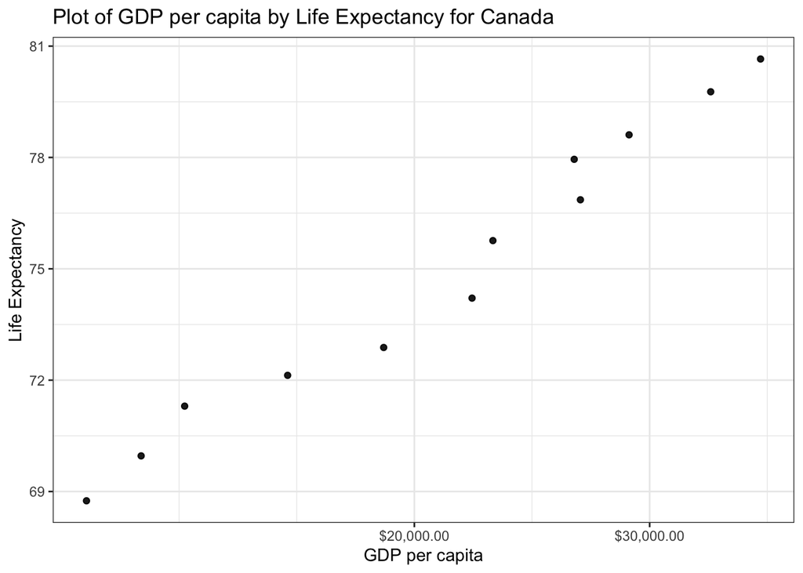

### **EXERCISE 2 - Explore individual variables with dplyr**

##### Pick one categorical variable and one quantitative variable to explore. Answer the following questions in whichever way you think is appropriate, using dplyr:

##### What are possible values (or range, whichever is appropriate) of each variable?

##### What values are typical? What’s the spread? What’s the distribution? Etc., tailored to the variable at hand.

#### > Exploring variables ‘Continent & Population’

A summary table of variable ‘Population’ for Continents

| continent | Mean | Median | Standard_Deviation | IQR | Mean_absolute_deviation | Min | Max | Range |
| --- | --- | --- | --- | --- | --- | --- | --- | --- |
| Africa | 9916003 | 4579311 | 15490923 | 9459415 | 5540861 | 60011 | 135031164 | 134971153 |
| Americas | 24504795 | 6227510 | 50979430 | 15377950 | 5972603 | 662850 | 301139947 | 300477097 |
| Asia | 77038722 | 14530830 | 206885205 | 42455955 | 18326691 | 120447 | 1318683096 | 1318562649 |
| Europe | 17169765 | 8551125 | 20519438 | 17471367 | 6626994 | 147962 | 82400996 | 82253034 |
| Oceania | 8874672 | 6403492 | 6506342 | 11152412 | 5996395 | 1994794 | 20434176 | 18439382 |

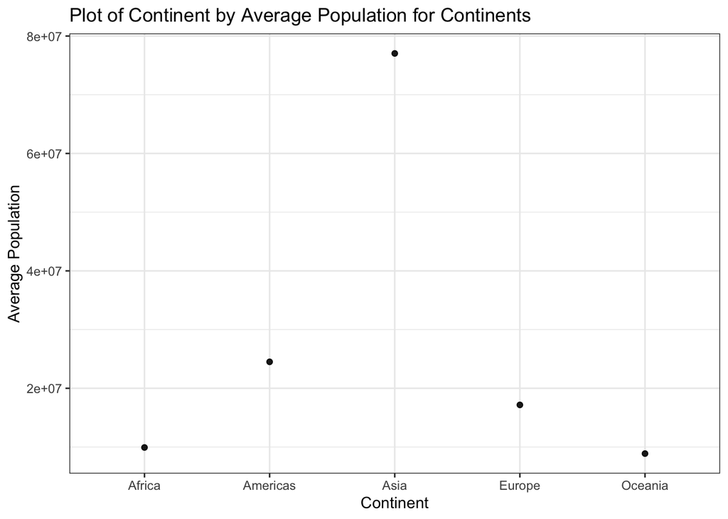

#### > Exploring variables ‘Continent & GDP per capita’

A summary table of variable ‘GDP per capita’ for Continents

| continent | mean | median | Standard_Deviation | IQR | Mean_Absolute_Deviation | Min | Max | Range |
| --- | --- | --- | --- | --- | --- | --- | --- | --- |
| Africa | 2193.755 | 1192.138 | 2827.930 | 1616.170 | 775.3226 | 241.1659 | 21951.21 | 21710.05 |
| Americas | 7136.110 | 5465.510 | 6396.764 | 4402.431 | 3269.3325 | 1201.6372 | 42951.65 | 41750.02 |
| Asia | 7902.150 | 2646.787 | 14045.373 | 7492.262 | 2820.8338 | 331.0000 | 113523.13 | 113192.13 |
| Europe | 14469.476 | 12081.749 | 9355.213 | 13248.301 | 8846.0506 | 973.5332 | 49357.19 | 48383.66 |
| Oceania | 18621.609 | 17983.304 | 6358.983 | 8072.258 | 6459.1033 | 10039.5956 | 34435.37 | 24395.77 |

##### From the table above, one can see that dispersion or spread (measured by Range) for GDP per capita is highest for Asia followed by Europe in second place. This statistic informs us that there are high extremes in per capita income in these places. The plot below shows that average GDP/capita (between 1952 and 2007) is highest for Oceania followed by Europe in second place and Asia in third place. The lowest average GDP/capita is seen in countries of Africa.

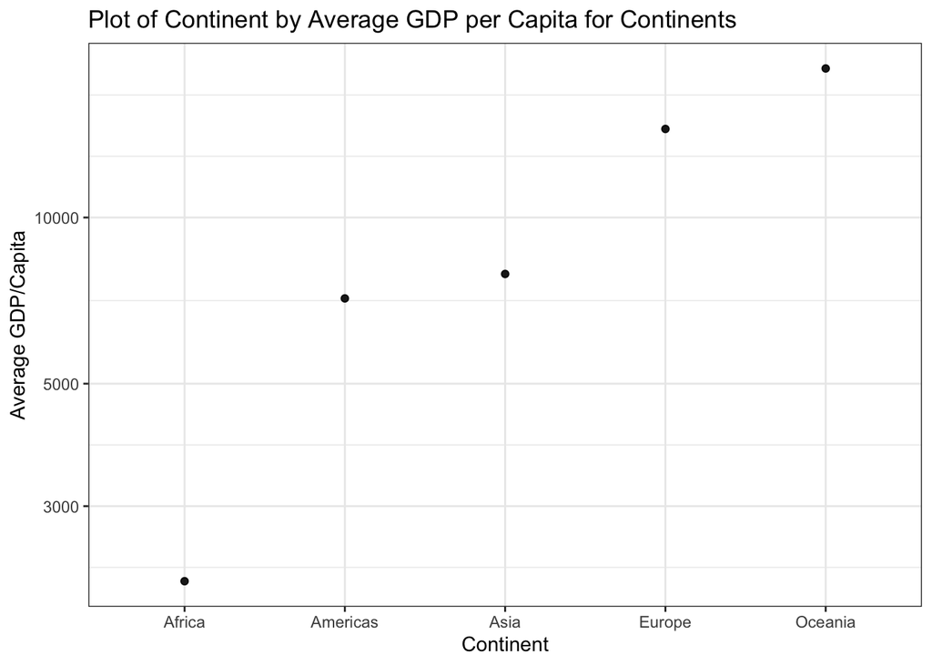

### **EXERCISE 3 - Explore various plot types**

#### **Scatterplot of GDP per capita by year for Denmark**

##### The plot below shows that GDP per capita of Denmark has steadily grown between 1952 and 2007. The upward trend of per capita GDP corresponds with high levels of happiness enjoyed by the country and similarly consistent high rankings in the World Happiness Rankings.

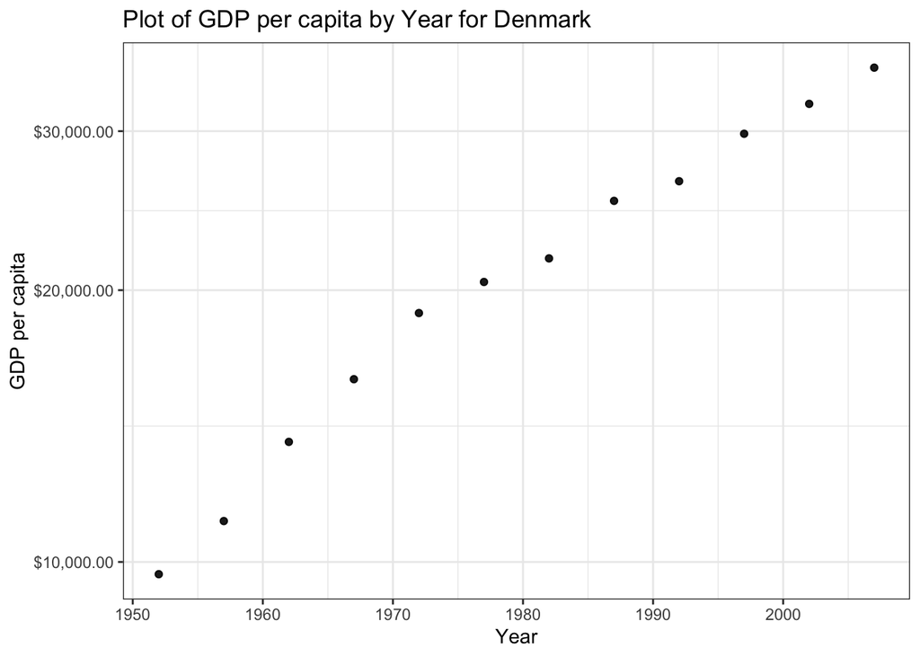

### **Bubble Charts**

#### **Per capita GDP growth in Developed vs Least Developed Countries**

##### Below are four bubblecharts (Fig 1-4) representing specific characteristics between 1952-2007 for two least developed vs two developed countries from the ‘gapminder’ dataset.

##### **Per capita GDP growth in Least Developed countries - Angola (Fig 1) & Cambodia (Fig 2)**

##### The point size in both plots represents life expectancy. For Angola (Fig 1), there is no clear relationship between GDP/capita and life expectancy over the years. In the initial years, there is a increase in life expectancy as GDP per capita increases but after the 1970s, although life expectancy is higher but GDP per capita declines until 2000 when with high life expectancy, GDP per capita starts increasing.

##### For Cambodia (Fig 2), there is a clearer positive relationship between life expectancy and GDP per capita. Life expectancy increases as GDP per capita continues to rise between 1952-2007. However, there is a short drop in per capita GDP between 1970-80 leading to a drastic decrease in life expectancy in the same period. After 1980, a high life expectancy remains stable with an increasing income.

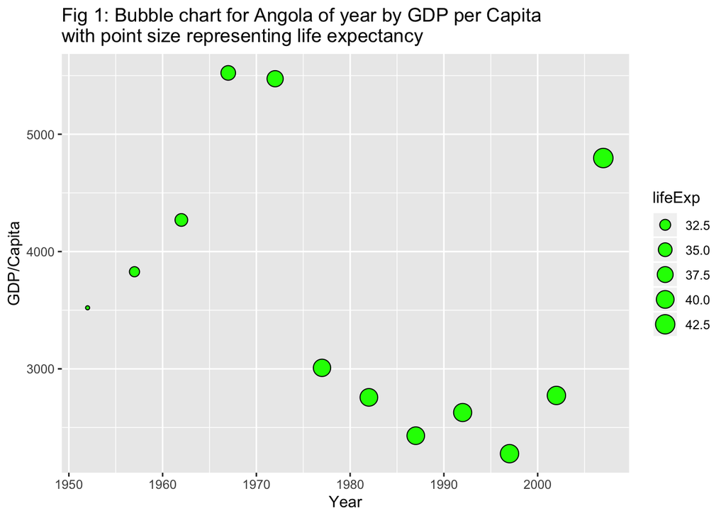

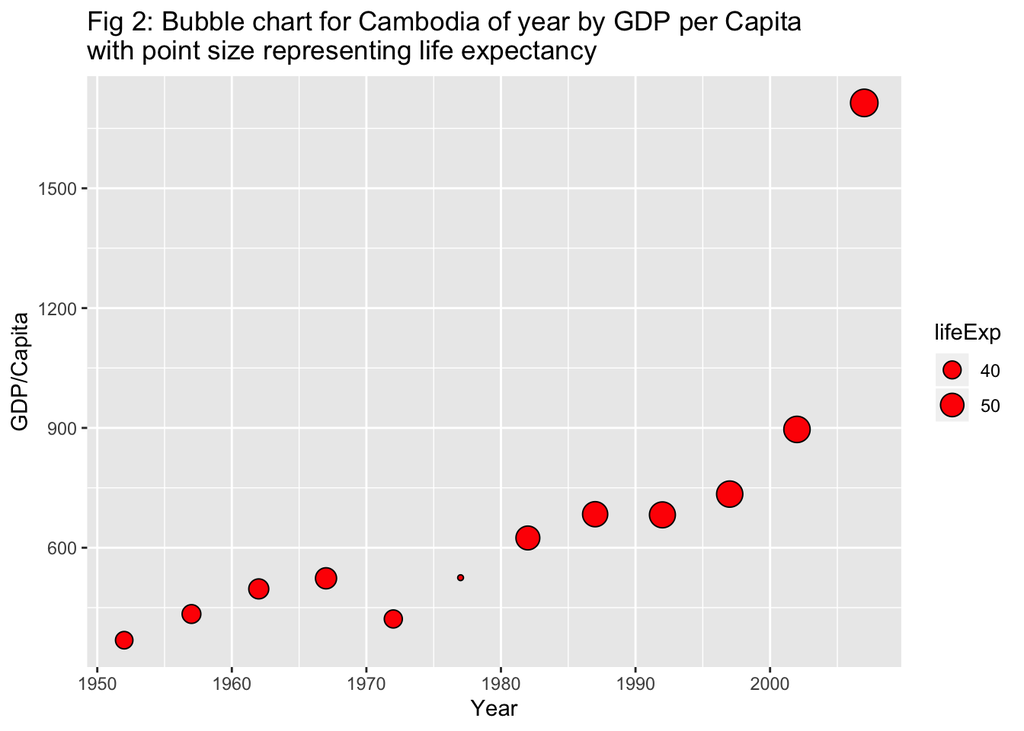

##### **Per capita GDP growth in Developed countries - Australia (Fig 3) & Norway (Fig 4)**

##### The point size in both plots represents life expectancy. For both the countries, there is a very clear positive relationship between GDP per capita and life expectancy over the years (1952-2007). As both countries continue to experience higher levels of income, people in these countries continue to achieve and enjoy better life conditions leading to a higher life expectancy.

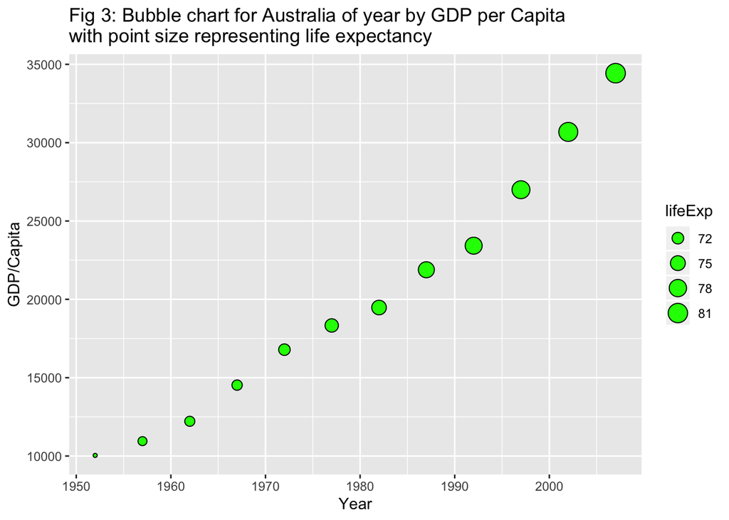

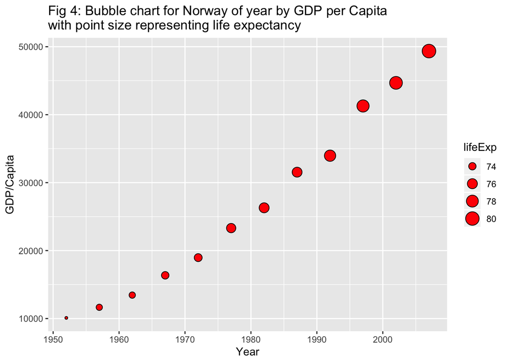

#### **Using dataset ‘mtcars’ to obtain scatterplots and bubble charts**

##### Using the dataset ‘mtcars’, a linear fit (Fig 5) is requested for variables weight (wt) and miles per gallon (mpg). The darker shaded area (band) represents 95% confidence interval. The red line represents a smoothed line for the linear model. Fig 6 is a bubble chart of car weight by mileage where point size represents gross horsepower. The plot shows that mileage decreases with an increase in weight and horsepower.

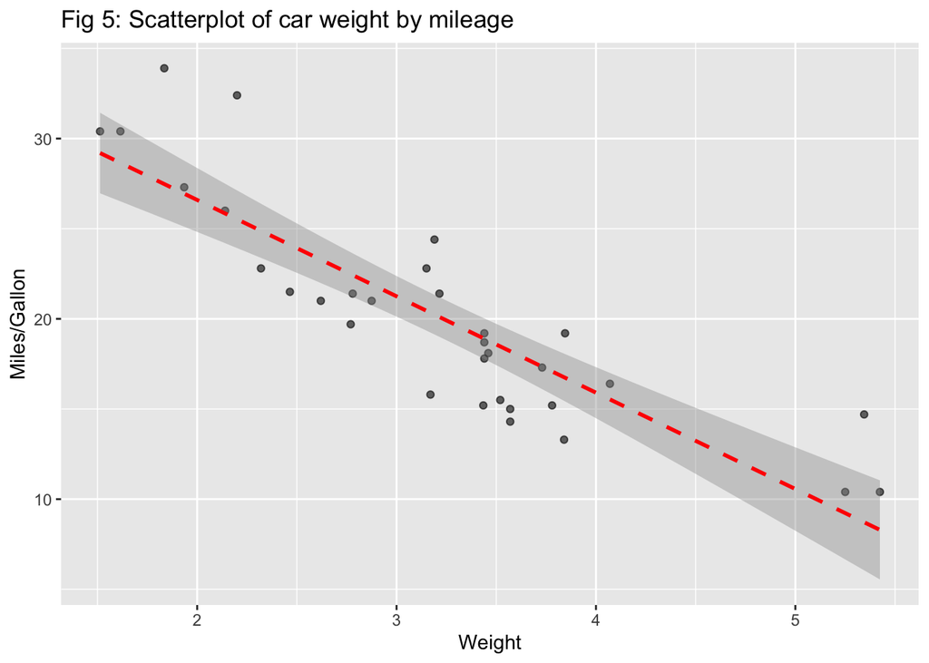

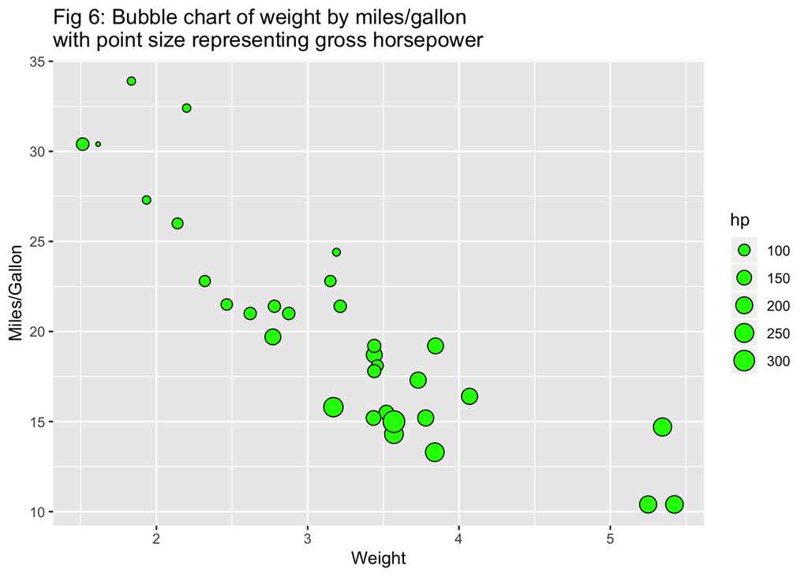

### **RECYCLING**

##### Below is the output from the code given in the assignment

OUTPUT OF GIVEN CODE

| country | continent | year | lifeExp | pop | gdpPercap |
| --- | --- | --- | --- | --- | --- |
| Afghanistan | Asia | 1957 | 30.332 | 9240934 | 820.8530 |
| Afghanistan | Asia | 1967 | 34.020 | 11537966 | 836.1971 |
| Afghanistan | Asia | 1977 | 38.438 | 14880372 | 786.1134 |
| Afghanistan | Asia | 1987 | 40.822 | 13867957 | 852.3959 |
| Afghanistan | Asia | 1997 | 41.763 | 22227415 | 635.3414 |
| Afghanistan | Asia | 2007 | 43.828 | 31889923 | 974.5803 |
| Rwanda | Africa | 1952 | 40.000 | 2534927 | 493.3239 |
| Rwanda | Africa | 1962 | 43.000 | 3051242 | 597.4731 |
| Rwanda | Africa | 1972 | 44.600 | 3992121 | 590.5807 |
| Rwanda | Africa | 1982 | 46.218 | 5507565 | 881.5706 |
| Rwanda | Africa | 1992 | 23.599 | 7290203 | 737.0686 |
| Rwanda | Africa | 2002 | 43.413 | 7852401 | 785.6538 |

##### Below is the output obtained after modifying the given code. The modified code differs from the given code in terms of the output it generates. The first code does not print variable values for all the years whereas the modified code prints variable values for all years listed in the dataset

OUTPUT OF MODIFIED CODE

| country | continent | year | lifeExp | pop | gdpPercap |
| --- | --- | --- | --- | --- | --- |
| Afghanistan | Asia | 1952 | 28.801 | 8425333 | 779.4453 |
| Afghanistan | Asia | 1957 | 30.332 | 9240934 | 820.8530 |
| Afghanistan | Asia | 1962 | 31.997 | 10267083 | 853.1007 |
| Afghanistan | Asia | 1967 | 34.020 | 11537966 | 836.1971 |
| Afghanistan | Asia | 1972 | 36.088 | 13079460 | 739.9811 |
| Afghanistan | Asia | 1977 | 38.438 | 14880372 | 786.1134 |
| Afghanistan | Asia | 1982 | 39.854 | 12881816 | 978.0114 |
| Afghanistan | Asia | 1987 | 40.822 | 13867957 | 852.3959 |
| Afghanistan | Asia | 1992 | 41.674 | 16317921 | 649.3414 |
| Afghanistan | Asia | 1997 | 41.763 | 22227415 | 635.3414 |
| Afghanistan | Asia | 2002 | 42.129 | 25268405 | 726.7341 |
| Afghanistan | Asia | 2007 | 43.828 | 31889923 | 974.5803 |
| Rwanda | Africa | 1952 | 40.000 | 2534927 | 493.3239 |
| Rwanda | Africa | 1957 | 41.500 | 2822082 | 540.2894 |
| Rwanda | Africa | 1962 | 43.000 | 3051242 | 597.4731 |
| Rwanda | Africa | 1967 | 44.100 | 3451079 | 510.9637 |
| Rwanda | Africa | 1972 | 44.600 | 3992121 | 590.5807 |
| Rwanda | Africa | 1977 | 45.000 | 4657072 | 670.0806 |
| Rwanda | Africa | 1982 | 46.218 | 5507565 | 881.5706 |
| Rwanda | Africa | 1987 | 44.020 | 6349365 | 847.9912 |
| Rwanda | Africa | 1992 | 23.599 | 7290203 | 737.0686 |
| Rwanda | Africa | 1997 | 36.087 | 7212583 | 589.9445 |
| Rwanda | Africa | 2002 | 43.413 | 7852401 | 785.6538 |
| Rwanda | Africa | 2007 | 46.242 | 8860588 | 863.0885 |